# handling_categorical

```python
import pandas as pd
from sklearn.model_selection import train_test_split
from sklearn.preprocessing import OneHotEncoder, OrdinalEncoder
from sklearn.compose import ColumnTransformer
from sklearn.pipeline import Pipeline
from sklearn.ensemble import RandomForestClassifier
from sklearn.metrics import accuracy_score
import matplotlib.pyplot as plt
import seaborn as sns
```

### Data Collection

```python
import requests

# URLs of the files
data_url = 'https://www.raphaelcousin.com/modules/module5/course/module5_course_handling_categorical.csv'

# Function to download a file
def download_file(url, file_name):
    response = requests.get(url)
    response.raise_for_status()  # Ensure we notice bad responses
    with open(file_name, 'wb') as file:
        file.write(response.content)
    print(f'Downloaded {file_name} from {url}')

# Downloading the files
download_file(train_data, 'module5_course_handling_categorical.csv')
```

```python
df = pd.read_csv("module5_course_handling_categorical.csv", sep=",")
```

## Data Analysis

```python
df
```

|  | class | cap-diameter | cap-shape | cap-surface | stem-width | has-ring |
| --- | --- | --- | --- | --- | --- | --- |
| 0 | e | Tiny | Convex | Hairy | 6.58 | f |
| 1 | e | Tiny | Convex | Dry | 33.89 | f |
| 2 | e | Tiny | Flat | Silky | 17.44 | t |
| 3 | e | Tiny | Flat | Hairy | 3.72 | f |
| 4 | p | Tiny | Bell | Textured | 6.08 | t |
| ... | ... | ... | ... | ... | ... | ... |
| 6101 | p | Colossal | Convex | Sticky | 6.67 | t |
| 6102 | p | Colossal | Sunken | Dry | 6.86 | f |
| 6103 | e | Gigantic | Sunken | Dry | 10.85 | f |
| 6104 | p | Colossal | Convex | missing | 13.56 | t |
| 6105 | p | Colossal | Bell | Grooved | 3.08 | f |

6106 rows × 6 columns

```python
df.info()
```

```
<class 'pandas.core.frame.DataFrame'>
RangeIndex: 6106 entries, 0 to 6105
Data columns (total 6 columns):
 #   Column        Non-Null Count  Dtype
---  ------        --------------  -----
 0   class         6106 non-null   object
 1   cap-diameter  6106 non-null   object
 2   cap-shape     6106 non-null   object
 3   cap-surface   6106 non-null   object
 4   stem-width    6106 non-null   float64
 5   has-ring      6106 non-null   object
dtypes: float64(1), object(5)
memory usage: 286.3+ KB
```

```python
# Identifying categorical columns by checking unique values or data type
categorical_columns = [col for col in df.columns if df[col].dtype == 'object' or df[col].nunique() < 11]
```

```python
df[categorical_columns].apply(lambda x: x.unique())
```

```
class                                                      [e, p]
cap-diameter    [Tiny, Moderate, Small, Medium, Fairly Large, ...
cap-shape       [Convex, Flat, Bell, Sunken, Others, Punctate,...
cap-surface     [Hairy, Dry, Silky, Textured, Grooved, Wrinkle...
has-ring                                                   [f, t]
dtype: object
```

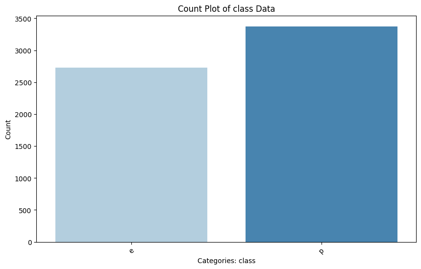

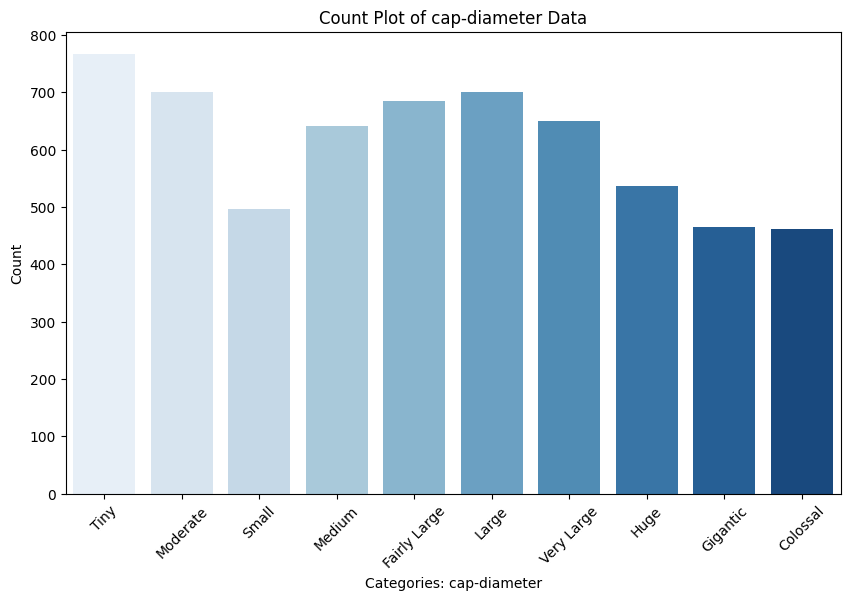

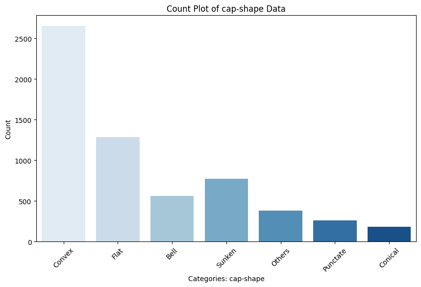

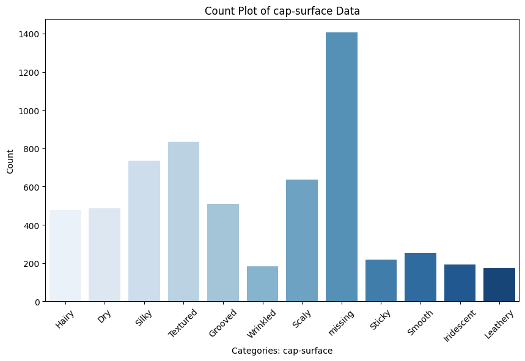

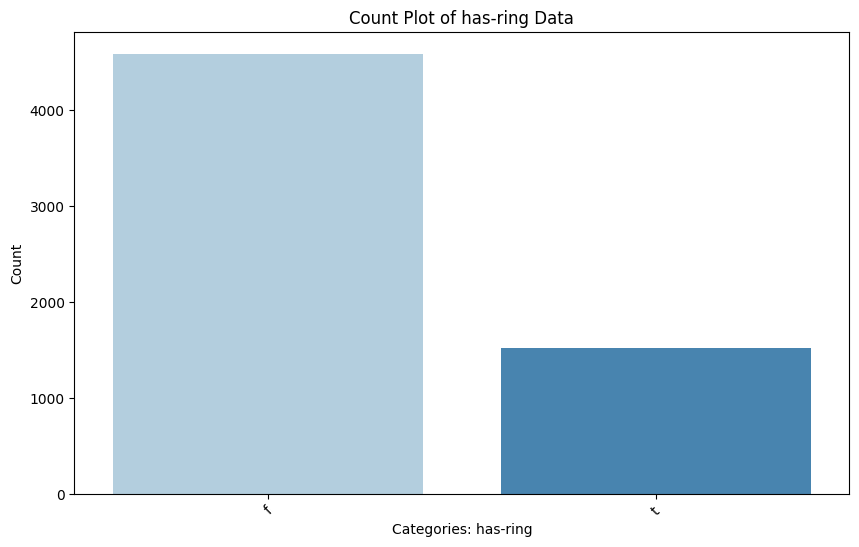

```python
for categorical_column in categorical_columns:
    plt.figure(figsize=(10, 6))
    sns.countplot(x=categorical_column, data=df, palette='Blues')
    plt.title(f'Count Plot of {categorical_column} Data')
    plt.xlabel(f'Categories: {categorical_column}')
    plt.ylabel('Count')
    plt.xticks(rotation=45)
    plt.show()
```

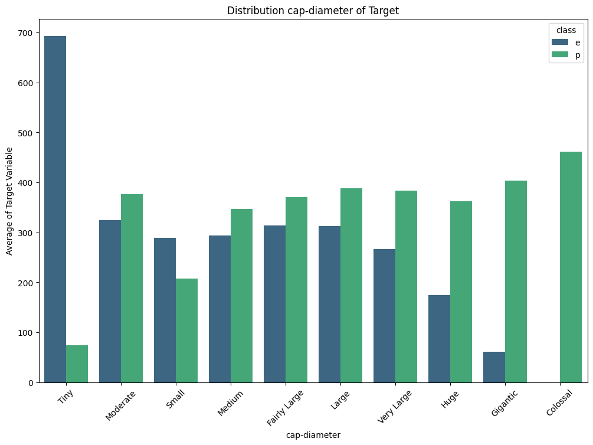

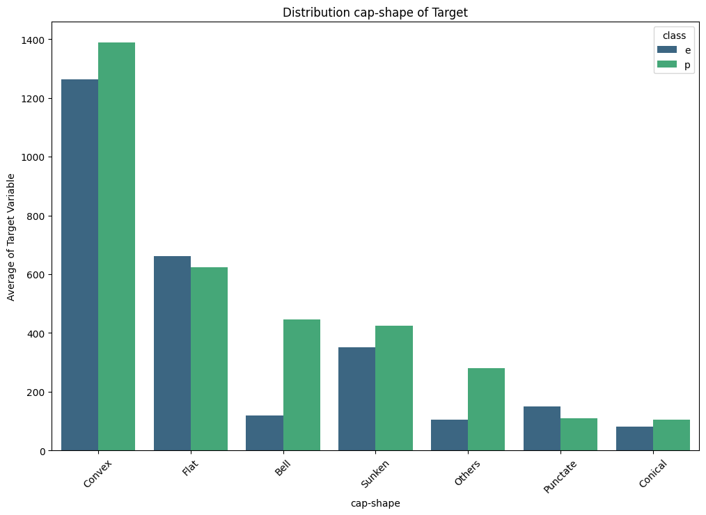

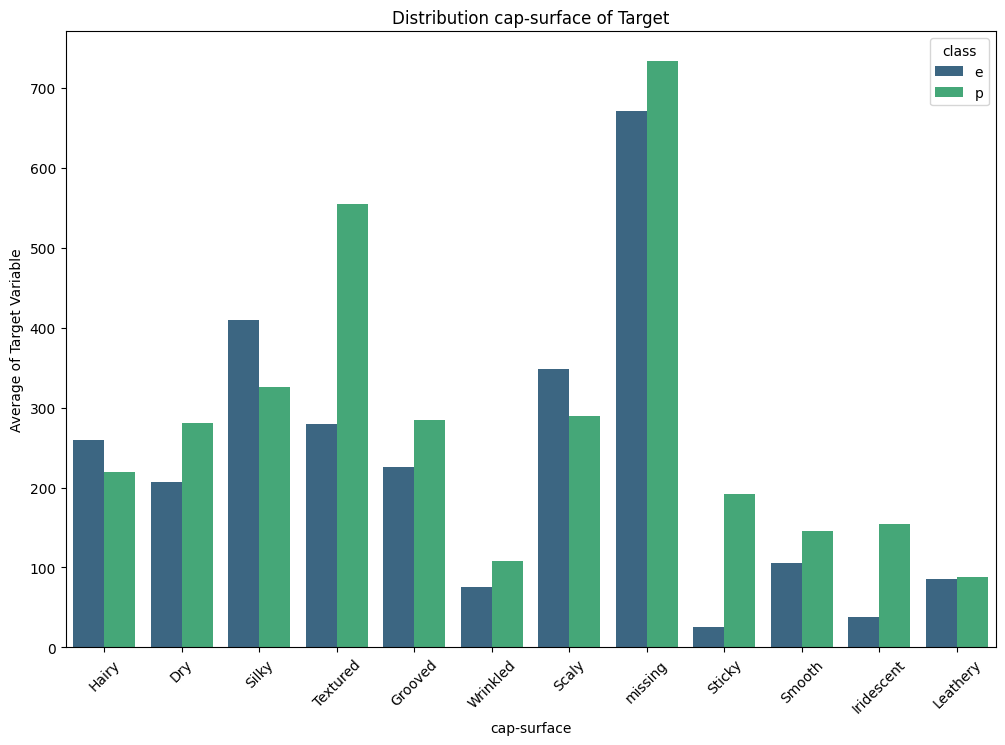

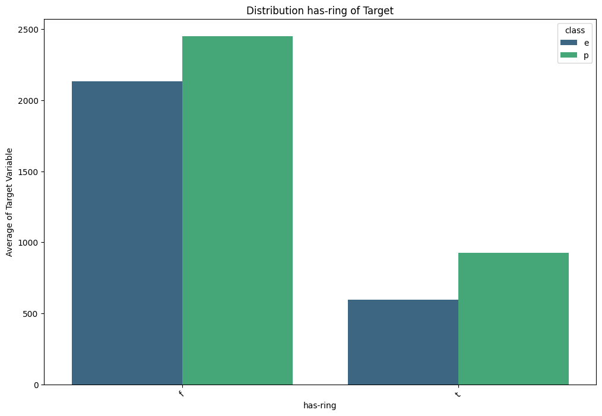

```python
for categorical_column in categorical_columns[1:]:
    plt.figure(figsize=(12, 8))
    sns.countplot(x=categorical_column, hue='class', data=df, palette='viridis')
    plt.title(f'Distribution {categorical_column} of Target')
    plt.xlabel(f'{categorical_column}')
    plt.ylabel('Average of Target Variable')
    plt.xticks(rotation=45)
    plt.show()
```

## Data Cleaning - Handling Categorical

```python
#split data into train and test sets
X = df.drop('class', axis=1)
y = df['class']
X_train, X_test, y_train, y_test = train_test_split(X, y, test_size=0.2, random_state=42)
```

1. **Handling Unseen Categories**: This method implements an OrdinalEncoder for each categorical column in a dataset, ensuring that unseen categories encountered during model testing do not cause errors by assigning them a default encoded value. This approach maintains data consistency between training and testing phases.

```python
from sklearn.linear_model import LogisticRegression
from sklearn.preprocessing import OrdinalEncoder
import numpy as np

def fit_encode(train, test):
    encoders = {}
    for col in train.columns:
        # Create the OrdinalEncoder for each column with handling for unseen categories
        oe = OrdinalEncoder(handle_unknown='use_encoded_value', unknown_value=-1)
        # Fit the encoder on the training data
        train[col] = oe.fit_transform(train[[col]])
        # Store the encoder in a dictionary to use for transforming the test data
        encoders[col] = oe
        # Transform the test data using the fitted encoder
        test[col] = oe.transform(test[[col]])
    return train, test

# Example data setup and usage
# Apply encoding to training and test sets
X_train_encoded, X_test_encoded = fit_encode(X_train.copy(), X_test.copy())

# Initialize and train the RandomForest model
model = LogisticRegression(random_state=42)
model.fit(X_train_encoded, y_train)
y_pred = model.predict(X_test_encoded)
print("Accuracy with correctly applied OrdinalEncoder:", accuracy_score(y_test, y_pred))
```

```
Accuracy with correctly applied OrdinalEncoder: 0.6268412438625205
```

2. **Simple One-Hot Encoding**: This approach uses one-hot encoding for categorical variables without any ordinal significance. It transforms categories into binary features, avoiding any ordinal assumptions and is suitable for nominal data where no inherent order is present.

```python
# Preprocessor setup without predefined ordinal mapping
preprocessor_simple = ColumnTransformer(
    transformers=[
        ('nom', OneHotEncoder(), ['cap-shape', 'cap-surface', 'cap-diameter', 'has-ring']),
    ])

# Pipeline with simple ordinal encoding
pipeline_simple = Pipeline(steps=[
    ('preprocessor', preprocessor_simple),
    ('classifier', LogisticRegression(random_state=42))
])

pipeline_simple.fit(X_train, y_train)
y_pred_simple = pipeline_simple.predict(X_test)
print("Accuracy with simple ordinal encoding:", accuracy_score(y_test, y_pred_simple))
```

```
Accuracy with simple ordinal encoding: 0.6824877250409165
```

```python
# Preprocessor setup without predefined ordinal mapping
preprocessor_simple = ColumnTransformer(
    transformers=[
        ('nom', OneHotEncoder(), ['cap-shape', 'cap-surface', 'has-ring']),
        ('ord', OrdinalEncoder(), ['cap-diameter'])
    ])

# Pipeline with simple ordinal encoding
pipeline_simple = Pipeline(steps=[
    ('preprocessor', preprocessor_simple),
    ('classifier', LogisticRegression(random_state=42))
])

fitted_pipeline = pipeline_simple.fit(X_train, y_train)
y_pred_simple = pipeline_simple.predict(X_test)
print("Accuracy with simple ordinal encoding:", accuracy_score(y_test, y_pred_simple))
```

```
Accuracy with simple ordinal encoding: 0.660392798690671
```

```python
preprocessor = fitted_pipeline.named_steps['preprocessor']
ordinal_encoder = preprocessor.named_transformers_['ord']
categories = ordinal_encoder.categories_
# Print the mapping for 'cap-diameter'
print("Mapping for 'cap-diameter':")
for idx, category in enumerate(categories[0]):  # Assuming 'cap-diameter' is the first and only column handled by OrdinalEncoder
    print(f"{category}: {idx}")
```

```
Mapping for 'cap-diameter':
Colossal: 0
Fairly Large: 1
Gigantic: 2
Huge: 3
Large: 4
Medium: 5
Moderate: 6
Small: 7
Tiny: 8
Very Large: 9
```

4. **Ordered Ordinal Encoding**: This method explicitly defines the order of categories for ordinal data before encoding. It is crucial for models that benefit from the ordinal relationship, as it ensures that the numerical representation reflects the inherent order of the categories, potentially improving model performance by preserving this information.

```python
# Define the correct order of categories for 'cap-diameter' and 'has-ring'
cap_diameter_order = ['Tiny', 'Small', 'Moderate', 'Medium', 'Fairly Large',
                      'Large', 'Very Large', 'Huge', 'Gigantic', 'Colossal']

# Setup the ColumnTransformer with the correct category ordering
preprocessor_ordered = ColumnTransformer(
    transformers=[
        ('nom', OneHotEncoder(), ['cap-shape', 'cap-surface', 'has-ring']),
        ('ord', OrdinalEncoder(categories=[cap_diameter_order]), ['cap-diameter'])
    ])

# Create and fit the pipeline
pipeline_ordered = Pipeline([
    ('preprocessor', preprocessor_ordered),
    ('classifier', LogisticRegression(random_state=42))
])
fitted_pipeline = pipeline_ordered.fit(X_train, y_train)
y_pred_ordered = pipeline_ordered.predict(X_test)

# Output the accuracy
print("Accuracy with ordered ordinal encoding:", accuracy_score(y_test, y_pred_ordered))
```

```
Accuracy with ordered ordinal encoding: 0.6882160392798691
```

```python
preprocessor = fitted_pipeline.named_steps['preprocessor']
ordinal_encoder = preprocessor.named_transformers_['ord']
categories = ordinal_encoder.categories_
# Print the mapping for 'cap-diameter'
print("Mapping for 'cap-diameter':")
for idx, category in enumerate(categories[0]):  # Assuming 'cap-diameter' is the first and only column handled by OrdinalEncoder
    print(f"{category}: {idx}")
```

```
Mapping for 'cap-diameter':
Tiny: 0
Small: 1
Moderate: 2
Medium: 3
Fairly Large: 4
Large: 5
Very Large: 6
Huge: 7
Gigantic: 8
Colossal: 9
```